# Using Multiple Regression and Analysis of Variance to Predict Portuguese High School Math Grades

Daniel Rendall, Jacob Schauer

4/20/2022

## Abstract

Improving the quality of education is a point of emphasis for many all over the world. This statistical analysis of a math class at two separate high schools in Portugal attempts to predict the final grade that a student will obtain while also seeing what factors contribute to the grade that student earns. The data was collected through school reports and questionnaires. The results from our multiple regression model show that the inputs that were collected can predict a student’s final grade with a high accuracy. However, the high predictive accuracy is almost entirely dependent on knowing a student’s previous grades. While there are other factors that contribute to a student’s achievement (such as romantic relationships and past failures), our analysis of this data shows that student achievement is almost exclusively influenced by past grades.

## Introduction

Like many countries, mathematics is a core high school class in Portugal. Therefore, it is important to be able to predict student’s achievement and to try to figure out if there are demographic, social, or lifestyle factors that contribute to the grades that a student earns. If we are able to predict performance and see why students are performing well or poorly, then administrators might be able to improve the schooling system, most notably for struggling students. A combination of grade reports and questionnaires were used to collect data on each student. The data will be modeled under a multiple regression model, where the output is a final grade that ranges between 0 and 20, where a grade of 20 is 100%.

## Exploratory Data Analysis

Before beginning the statistical analysis, we must perform some exploratory data analysis. The figure below is a boxplot of the final grade a student received in the math class grouped by the number of classes a student has failed in the past. Below the figure is a table of the mean final grades grouped by past class failures.

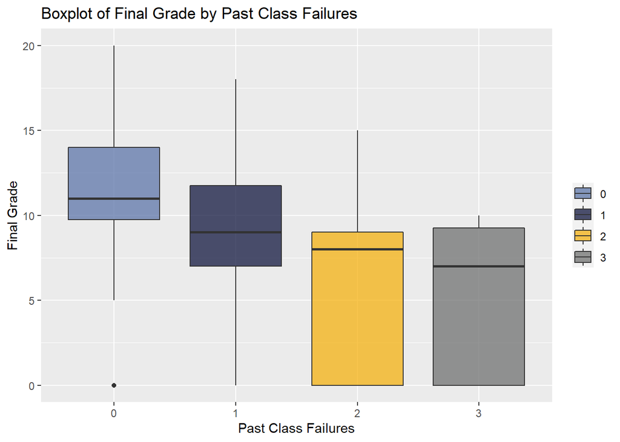

| failures | mean |
| --- | --- |
| 0 | 11.253205 |
| 1 | 8.120000 |
| 2 | 6.235294 |
| 3 | 5.687500 |

It appears from the above figure and this table that past class failures could be a relevant predictor of class performance.

Another potentially relevant variable is whether or not a student is in a romantic relationship. A student in a romantic relationship might be distracted and less inclined to study, and might do more poorly in the class.

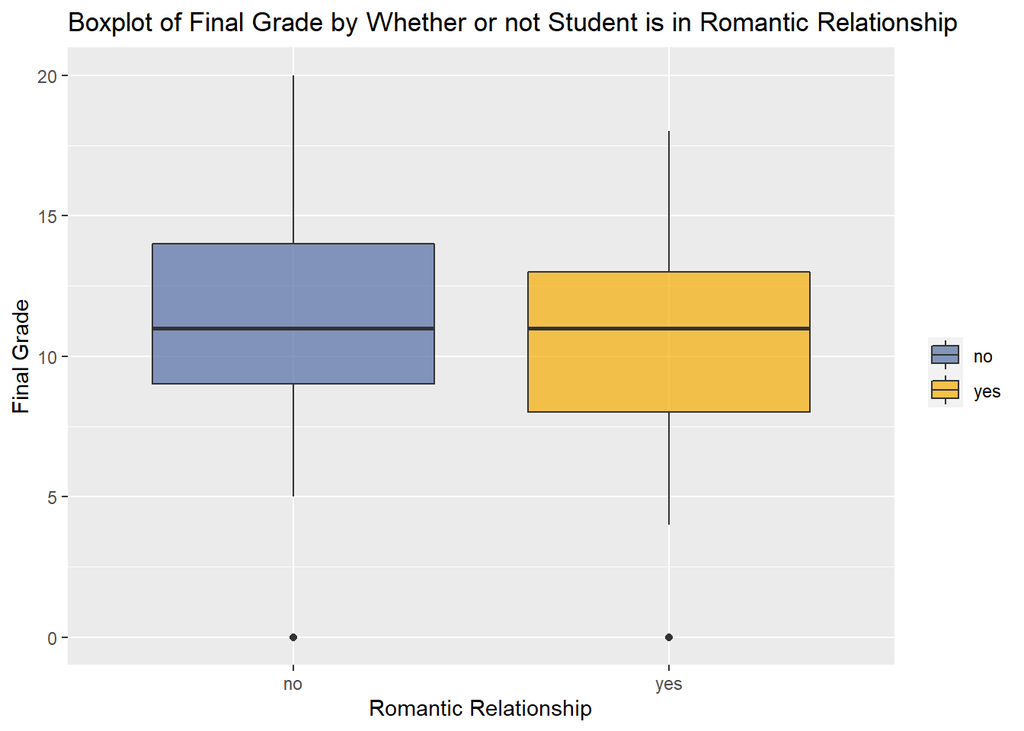

The above boxplot does not show convincing evidence that a romantic relationship has any effect on final grade.

These high schools in Portugal had a grading system where there were three grading periods: grade period 1, grade period 2, and grade period 3, where grade period 3 is the final grade period that we are trying to predict. Plotting a student’s previous grades against their final grade show a very strong relationship. Here is a plot of student’s first period grade against their final grade.

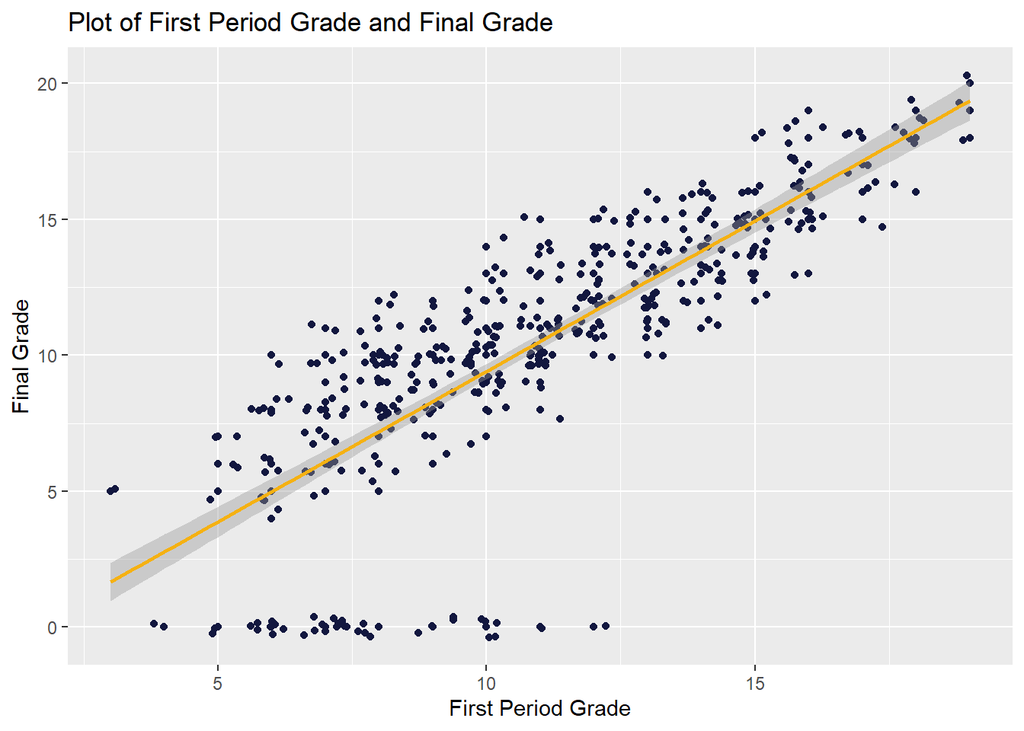

The plot of student’s second period grade against their final grade tells a very similar story:

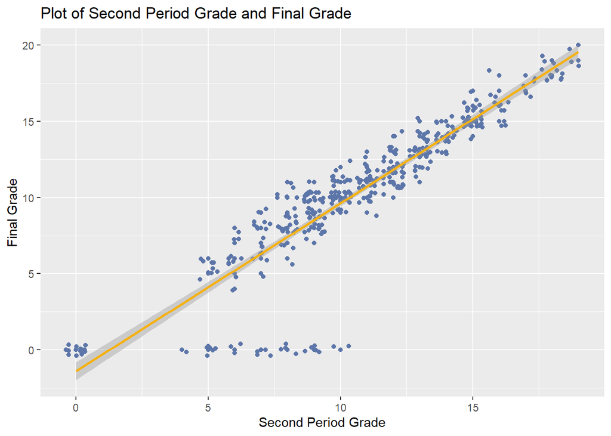

Based on these two plots, it appears that student’s previous grades are vital for accurately predicting performance.

Another thing we can do before we predict final grades is see if any numeric predictors are highly correlated with eachother. If two predictors are highly correlated, it will inflate the variance of the estimated coefficients of those predictors which may make it more difficult to make accurate predictions.

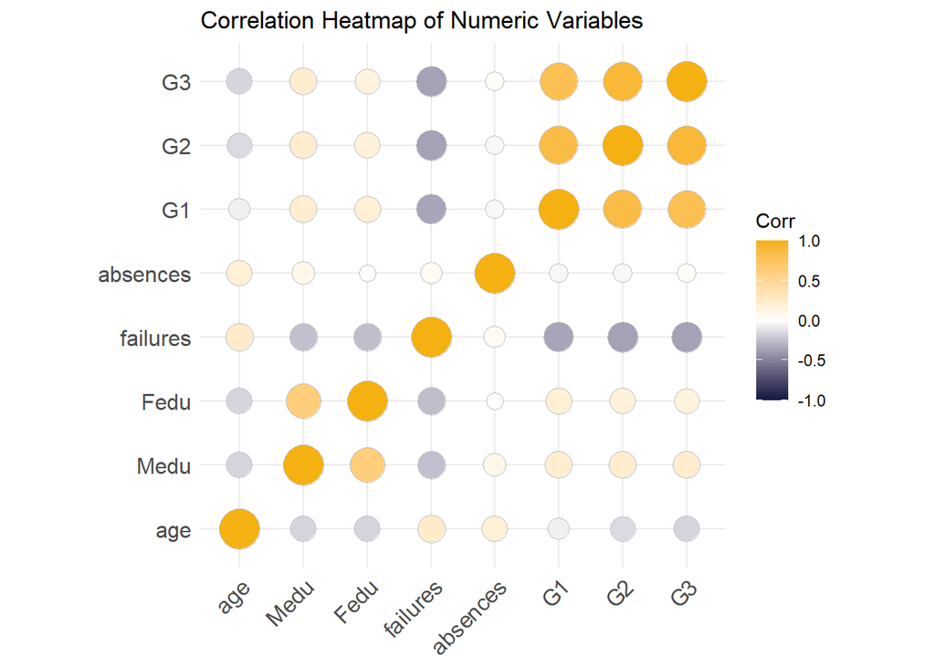

Besides the aforementioned 1st period grade and 2nd period grade, there do not appear to be any strongly correlated predictors from this figure.

## Statistical Analysis

First, we fit a multiple regression model to the data to try and predict student performance. Before we make any conclusions based on our model, we must check for two assumptions: we must make sure that there is constant variability in the residuals, and make sure the residuals are nearly normal.

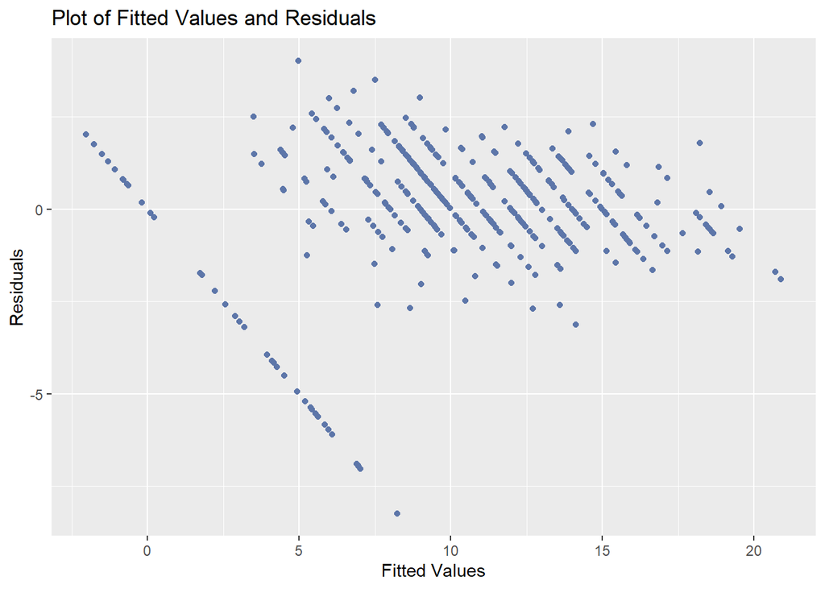

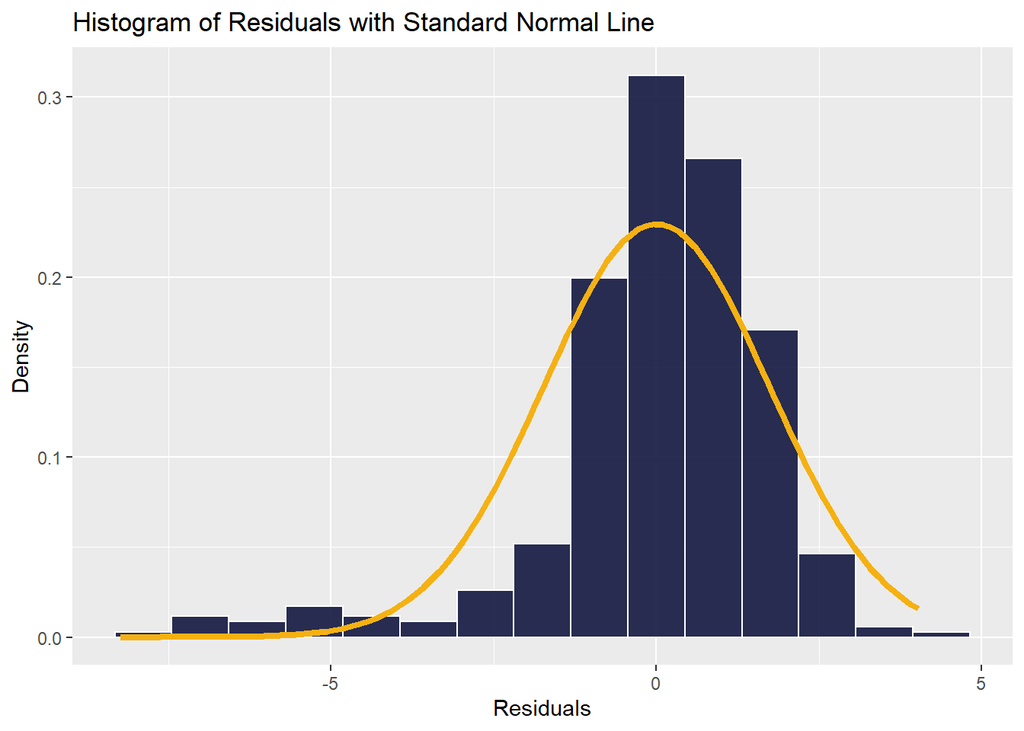

There does not appear to be a concerning pattern in the residual plot, and the residuals appear to be nearly normal. We are comfortable to proceed with the regression analysis. The r-squared and adjusted r-squared values of our model are displayed below.

```
## [1] 0.8561172
```

```
## [1] 0.8287316
```

The fact that over 85% of the variation in these students final grades can be explained by our model is very encouraging. It appears we are able to predict final grades with a high amount of accuracy.

The next part of our analysis is to see which variables are best able to predict final grades. It is clear from our exploratory data analysis that previous grades are a very strong indicator of future grades. We ran a regression where the only predictors were 1st period grade and 2nd period grade. The r-squared and adjusted r-squared values are below.

```
## [1] 0.8221632
```

```
## [1] 0.8212559
```

These outputs make it clear that previous grades are carrying most of the weight in predicting final grade. Over 82% of the variability in final grade can be explained by 1st period grade and 2nd period grade alone. The adjusted r-squared values (which are useful when comparing two regression models with a different number of predictors) are almost identical. We used an F-test to see if the complete model is any better at predicting final grade than the reduced model. The results of that test are below.

```
## Analysis of Variance Table
##
## Model 1: G3 ~ school + sex + age + address + famsize + Pstatus + Medu +
##     Fedu + Mjob + Fjob + reason + guardian + traveltime + studytime +
##     failures + schoolsup + famsup + paid + activities + nursery +
##     higher + internet + romantic + famrel + freetime + goout +
##     Dalc + Walc + health + absences + G1 + G2
## Model 2: G3 ~ G1 + G2
##   Res.Df    RSS  Df Sum of Sq      F  Pr(>F)
## 1    331 1189.9
## 2    392 1470.7 -61    -280.8 1.2805 0.09119 .
## ---
## Signif. codes:  0 '***' 0.001 '**' 0.01 '*' 0.05 '.' 0.1 ' ' 1
```

The p-value of .09119 means that we cannot reject the null hypothesis at the 5% level. There is not enough evidence that our complete model is any more useful than a model with only first period and second period grades as predictors. This confirms a suspicion we had after our exploratory data analysis: these student’s final grades are almost exclusively explained by their previous grades. Next, we will look at a few predictors that were statistically significant at the 5% level in the model and analyze them closer.

Holding all other regressors fixed, a student in a romantic relationship is estimated to get a grade .45 points lower than someone not in a romantic relationship. A table of the mean grades by romantic relationship is below.

| romantic | mean |
| --- | --- |
| no | 10.836502 |
| yes | 9.575758 |

Next, we perform a t-test to see if there is a difference in mean final grade between those in a romantic relationship and those not in one.

```
##
##  Welch Two Sample t-test
##
## data:  G3 by romantic
## t = 2.5122, df = 240.07, p-value = 0.01266
## alternative hypothesis: true difference in means between group no and group yes is not equal to 0
## 95 percent confidence interval:
##  0.2721553 2.2493333
## sample estimates:
##  mean in group no mean in group yes
##         10.836502          9.575758
```

This t-test says we can reject the null hypothesis of equal means at the 5% level. We are 95% confident the true mean difference in final grades between those not in a romantic relationship and those in a romantic relationship is within the interval [.27, 2.25].

Previous class failures is a predictor that is not statistically significant, but it is also somewhat negatively correlated with first and second period grade, the two strongest predictors. A table of mean final grade by previous class failures is below.

| failures | mean |
| --- | --- |
| 0 | 11.253205 |
| 1 | 8.120000 |
| 2 | 6.235294 |
| 3 | 5.687500 |

We perform an analysis of variance F-test to see if there is a difference between any of these mean final grades.

```
##              Df Sum Sq Mean Sq F value   Pr(>F)
## failures      1   1074  1074.3   58.67 1.47e-13 ***
## Residuals   393   7196    18.3
## ---
## Signif. codes:  0 '***' 0.001 '**' 0.01 '*' 0.05 '.' 0.1 ' ' 1
```

This shows that the mean final grades grouped by previous class failures are not the same across the four groups. Next, we perform Tukey’s Honest Significant Differences to see which means are different from eachother.

|  | diff | lwr | upr | p adj |
| --- | --- | --- | --- | --- |
| 1-0 | -3.1332051 | -4.811899 | -1.4545111 | 0.0000125 |
| 2-0 | -5.0179110 | -7.762490 | -2.2733319 | 0.0000198 |
| 3-0 | -5.5657051 | -8.390450 | -2.7409605 | 0.0000034 |
| 2-1 | -1.8847059 | -4.978615 | 1.2092028 | 0.3960261 |
| 3-1 | -2.4325000 | -5.597739 | 0.7327392 | 0.1962149 |
| 3-2 | -0.5477941 | -4.386210 | 3.2906222 | 0.9829264 |

These intervals and p-values show that there are differences between those who have no previous class failures and those who have any previous class failures. However, there is not enough evidence to suggest that having 1 previous class failure is any different from having multiple previous class failures. It is interesting that even though previous class failures is not significant in our regression, it is still something that can predict whether or not a student will do well or poorly in the class. This is likely because previous class failures is negatively correlated with first and second period grade. This likely inflated the standard error of the estimated coefficient on failures. When a regression is performed without first and second period grades included as regressors, the coefficient on failures is -1.71 with a p-value of .0000006.

Another significant predictor in our model is how often a student goes out to hang out with friends. A table and visual of mean final grade by how often a student reports they go out with friends is below. The data was collected on a 1-5 scale where 1 means a student goes out with friends at a very low rate and 5 means a student goes out with friends at a very high rate.

| goout | mean |
| --- | --- |
| 1 | 9.869565 |
| 2 | 11.194175 |
| 3 | 10.961538 |
| 4 | 9.651163 |
| 5 | 9.037736 |

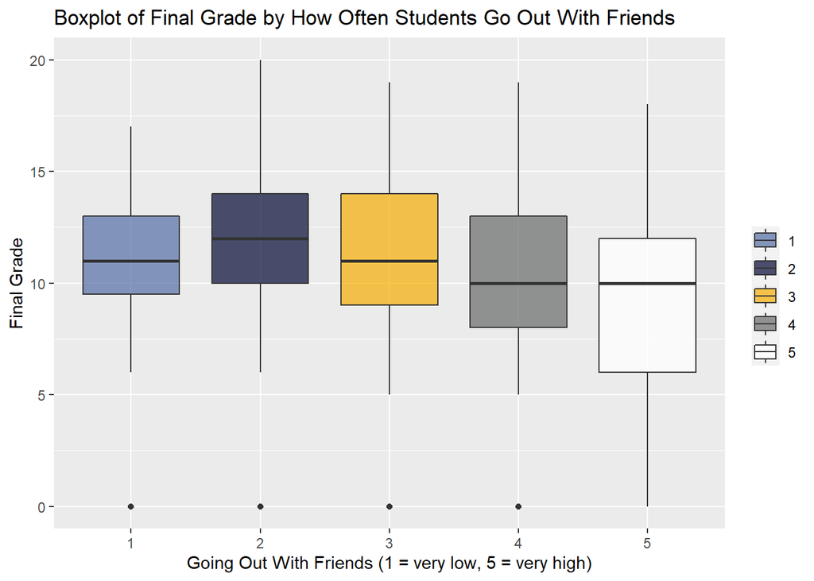

The results of our analysis of variance test are below.

```
##              Df Sum Sq Mean Sq F value Pr(>F)
## goout         4    259   64.73   3.151 0.0144 *
## Residuals   390   8011   20.54
## ---
## Signif. codes:  0 '***' 0.001 '**' 0.01 '*' 0.05 '.' 0.1 ' ' 1
```

There is evidence at the 5% level that there is a difference in these means. The Tukey’s Honest Significant Difference results are below.

|  | diff | lwr | upr | p adj |
| --- | --- | --- | --- | --- |
| 2-1 | 1.3246095 | -1.539942 | 4.1891608 | 0.7114664 |
| 3-1 | 1.0919732 | -1.717753 | 3.9016993 | 0.8243028 |
| 4-1 | -0.2184024 | -3.134177 | 2.6973723 | 0.9996036 |
| 5-1 | -0.8318294 | -3.933237 | 2.2695779 | 0.9481981 |
| 3-2 | -0.2326363 | -1.871118 | 1.4058452 | 0.9951370 |
| 4-2 | -1.5430120 | -3.357345 | 0.2713207 | 0.1373977 |
| 5-2 | -2.1564389 | -4.256150 | -0.0567275 | 0.0408022 |
| 4-3 | -1.3103757 | -3.036849 | 0.4160975 | 0.2307900 |
| 5-3 | -1.9238026 | -3.948079 | 0.1004737 | 0.0714703 |
| 5-4 | -0.6134269 | -2.782500 | 1.5556457 | 0.9376881 |

This shows that there is a difference in mean final grade between those who went out with friends a moderate amount (2) and those who went out at a very high rate (5).

Another significant predictor is reported weekday alcohol consumption. This variable was a factor on a scale of 1-5, where 1 is very little weekday drinking, and 5 is a very high rate of weekday drinking. Here is a table of the mean final grade by each level of weekday drinking and a boxplot.

| Dalc | mean |
| --- | --- |
| 1 | 10.731884 |
| 2 | 9.253333 |
| 3 | 10.500000 |
| 4 | 9.888889 |
| 5 | 10.666667 |

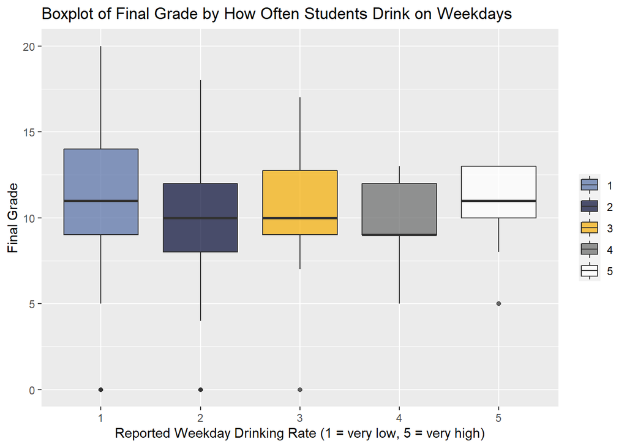

The analysis of variance test results are below.

```
##              Df Sum Sq Mean Sq F value Pr(>F)
## Dalc          4    132   33.04   1.584  0.178
## Residuals   390   8138   20.87
```

Even though this p-value indicates we don’t have enough evidence in a mean difference between the mean final grades by weekday drinking, that doesn’t necessarily mean it’s not an important factor. All of the coefficients on weekday drinking were significant and negative. The below bar chart shows us some issues with making conclusions with this variable. The results are heavily skewed, with most people saying they rarely drink during the weekend, making it difficult to get good final grade means for the higher drinking levels.

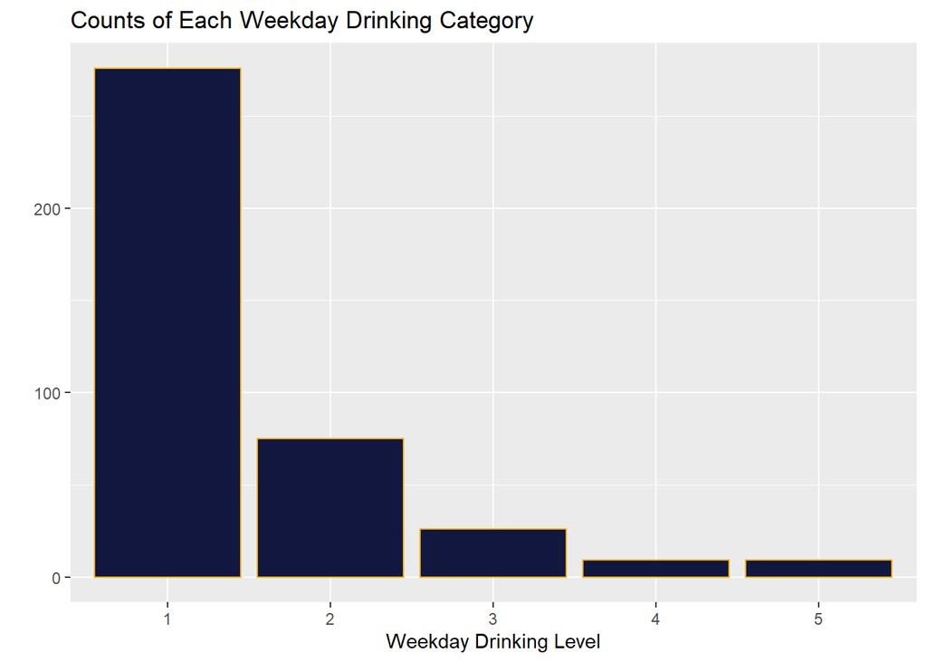

```r
ggplot(data = math, aes(x = Dalc))+
  geom_bar(fill = '#12173F', color = '#F5B112') +
  labs(title = 'Counts of Each Weekday Drinking Category', x = 'Weekday Drinking Level', y = '')
```

Another predictor that was significant in this model was number of absences. Holding all other regressors fixed, an additional absence was associated with an .043 increase in grade. Even though absences was statistically significant, it is not practically significant.

## Conclusion

We used multiple regression to predict the final grade in a Portuguese math class and used various analysis of variance tests to see what factors might contribute to the grade that a student earns. Based on our analysis, the main predictive factor for final grades is previous grades. However, a few other predictors also can help explain these student’s grades. Students who are not in a romantic relationship, who go out with friends a moderate amount of time (but not too much or too little), and students who have not failed any previous classes also tended to perform better in this math class. We felt this model may have been missing an IQ variable or some other intelligence quantifier besides grade. It also would have been interesting to see multiple time periods and classes for the same students to see if any changes in their health, support, etc. was a contributor in their grades. While previous grades has a huge influence on final grades, these conclusions can still help improve the school system and catch students who at risk to do poorly before they start to fail.